Hi Jerin, I saw your nice RMSE matrix. So I tried out making a matrix of Recursive Cross Validation MSEs introduced in the textbook.

### Choose the Best Model Based on Recursive Cross Validation MSEs

#### The First Difference of the Training Data Is Stationary

Assume we only have the 80% training data available when we forecast. The 80% training data don’t pass the ADF stationarity test. But their first difference does under the 5% critical value.

[figure not shown]

The ACF and the PACF oscillating decay, suggesting an ARMA process.

#### Recursive Cross Validation MSEs

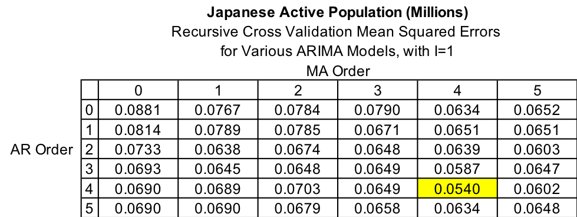

I wrote a function to carry out the recursive cross validation and output the table. The MSE comparison table shows the ARIMA(4,1,4) has the lowest MSE calculated from the Recursive Cross Validation method introduced in the textbook. So I’ll model and forecast the series with ARIMA(4,1,4)

```
Estimate the Training Set Using ARIMA(4,1,4)

      Estimate Std. Error  z value  Pr(>|z|)
ar1  2.7311363  0.0033779  808.520 < 2.2e-16 ***
ar2 -3.7286554  0.0064473 -578.331 < 2.2e-16 ***
ar3  2.7274733  0.0053904  505.990 < 2.2e-16 ***
ar4 -0.9975692  0.0020584 -484.635 < 2.2e-16 ***
ma1 -2.7497406  0.0232984 -118.023 < 2.2e-16 ***
ma2  3.6476985  0.0503088   72.506 < 2.2e-16 ***
ma3 -2.5778123  0.0572837  -45.001 < 2.2e-16 ***
ma4  0.8892083  0.0329816   26.961 < 2.2e-16 ***
---
Signif. codes:  0 ‘***’ 0.001 ‘**’ 0.01 ‘*’ 0.05 ‘.’ 0.1 ‘ ’ 1

sigma^2 estimated as 0.04659:  log likelihood=48.52
AIC=-79.04   AICc=-78.63   BIC=-42.03

Training set error measures:
                    ME      RMSE       MAE        MPE      MAPE      MASE       ACF1
Training set 0.0392432 0.2136924 0.1660205 0.07214487 0.2982637 0.3391162 -0.1006613
```

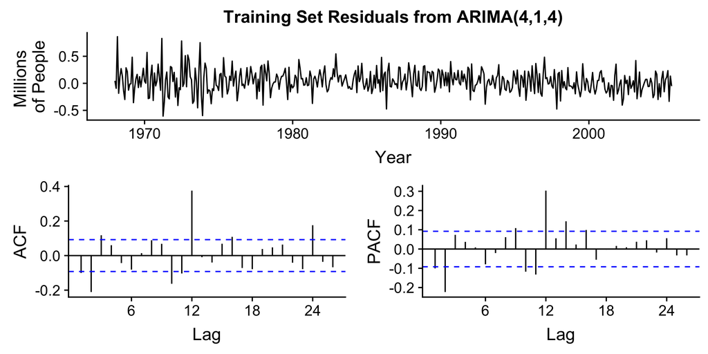

Using ARIMA(4,1,4), the training set residuals pass the ADF test of stationarity with a p-value less than 0.01, but not the Box-Ljung test of independence.

#### Forecast Using ARIMA(4,1,4)

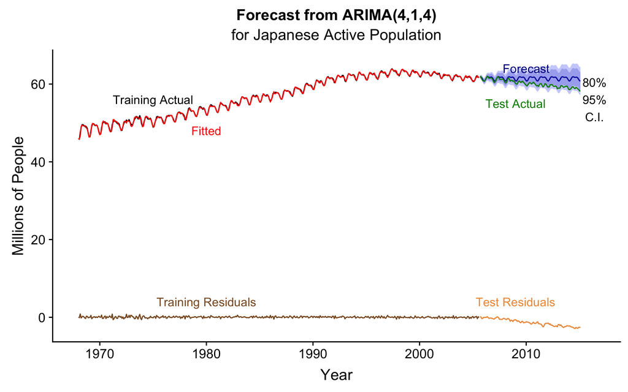

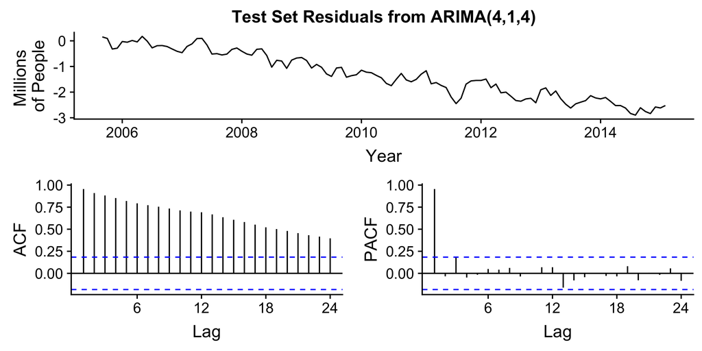

```
                     ME      RMSE       MAE         MPE      MAPE
Training set  0.0392432 0.2136924 0.1660205  0.07214487 0.2982637
Test set     -1.3318812 1.5986724 1.3427450 -2.23559760 2.2531485
                  MASE       ACF1 Theil's U
Training set 0.3391162 -0.1006613        NA
Test set     2.7427130  0.9553236  5.477685
```

Next, I’m thinking about how we can reconcile the forecast performance and the in-same performace. ARIMA(4,1,4) has a low MSE but its AIC is higher than my previous ARIMA model.

rmarkdown::render(“Post2U4IA.Rmd”)